# Exploratory Data Analysis - Football

Tarun Reddy Aleti

April 14th, 2016

### Executive Summary

- The data set at hand covers all the “Serie A” football matches for the last 8 years of Italian Football League.
- Our goal is to do preliminary exploratory data analysis
- The dataset for the model can be downloaded from [train](https://inclass.kaggle.com/c/football-data-challenge/download/train.csv), [test](https://inclass.kaggle.com/c/football-data-challenge/download/test.csv)

#### Required Packages

Following packages are required for the code to run efficiently.

```r
library(MASS)
library(plyr)
library(knitr)
library(sqldf)
library(ggplot2)
```

#### Preliminary Analysis

For the code to execute, all the datasets should be in the R working directory. The datasets are in .csv format.

```r
set.seed(1)
data <- read.csv("train.csv", header = TRUE, stringsAsFactors = FALSE)
final_test <- read.csv("test.csv", header = TRUE, stringsAsFactors = FALSE)
final_test$FTR <- NA
full_data <- rbind(data, final_test)
```

- The data set under consideration has a total of **1520** rows and **21** independent variables. Our dependent variable is *FTR (Full Time Result)* and is a categorical variable, wherein **A** indicates that Away team won, **H** indicates that home team won and **D** indicates that result was a draw
- Independent Variables are as follows
  1. *Date*: Indicates when the match was played
     - Can extract Weekday/Weekend, DayofWeek and Month information
  2. *HomeTeam*: Name of Home Team in the match
     - There are 27 different teams. We might need to create dummy variables for them.
     - The team names are Sampdoria, Verona, Cagliari, Inter, Lazio, Livorno, Napoli, Parma, Torino, Fiorentina, Chievo, Juventus, Atalanta, Bologna, Catania, Genoa, Milan, Roma, Sassuolo, Udinese, Palermo, Lecce, Reggina, Siena, Bari, Cesena, Brescia.
  3. *AwayTeam*: Name of Away Team in the match
     - There are 27 different teams. We might need to create dummy variables for them.
     - The team names are Juventus, Milan, Atalanta, Genoa, Udinese, Roma, Bologna, Chievo, Sassuolo, Catania, Napoli, Lazio, Torino, Sampdoria, Inter, Fiorentina, Cagliari, Verona, Livorno, Parma, Palermo, Siena, Reggina, Lecce, Bari, Cesena, Brescia.
     - There are same number of Home Teams as Away Teams
  4. *B365H*: Bet365 home win odds
  5. *B365D*: Bet365 draw odds
6. *B365A*: Bet365 away win odds
7. *BWH*: Bet&Win home win odds
8. *BWD*: Bet&Win draw odds
9. *BWA*: Bet&Win away win odds
10. *IWH*: Interwetten home win odds
11. *IWD*: Interwetten draw odds
12. *IWA*: Interwetten away win odds
13. *LBH*: Ladbrokes home win odds
14. *LBD*: Ladbrokes draw odds
15. *LBA*: Ladbrokes away win odds
16. *VCH*: VC Bet home win odds
17. *VCD*: VC Bet draw odds
18. *VCA*: VC Bet away win odds
19. *WHH*: William Hill home win odds
20. *WHD*: William Hill draw odds
21. *WHA*: William Hill away win odds

### Exploratory Data Analysis

1. *Frequency of Results*:

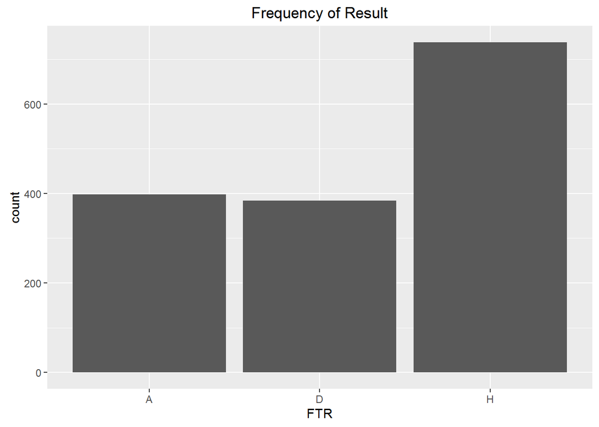

```r
ggplot(data, aes(FTR)) + geom_bar() + ggtitle('Frequency of Result')
```

Home team is more likely to win compare to Away Team or Draw Result. We can use Home Team as our Reference in Analysis

2. Frequency of Games played by Teams at Home:

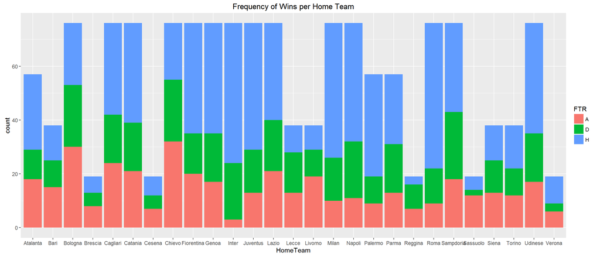

```r
ggplot(data, aes(HomeTeam, fill = FTR)) + geom_bar() + ggtitle('Frequency of Wins per Home Team')
```

3. Frequency of Games played by Teams Away:

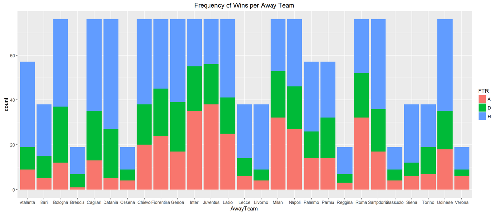

```r
ggplot(data, aes(AwayTeam, fill = FTR)) + geom_bar() + ggtitle('Frequency of Wins per Away Team')
```

4. Average Ratings per Result type for Home Team

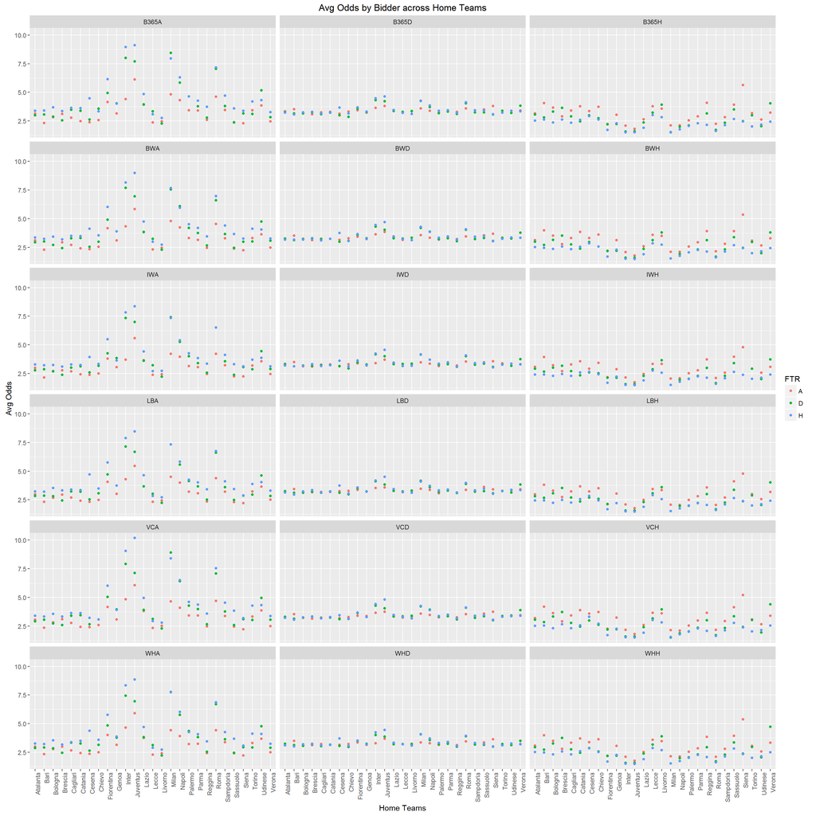

```r
query <- paste("SELECT ", paste('avg(', colnames(data)[6:23], '),', collapse = ""), " HomeTeam, FTR ",
               "FROM data
                GROUP BY HomeTeam, FTR", sep = "")
avg_data <- sqldf(query)
colnames(avg_data) <- c(paste('avg', colnames(data)[6:23], sep = "_"), "HomeTeam", "FTR")
l_avg_data <- alply(avg_data[ ,-c(19, 20)], 2, function(x){
                                                 y <- cbind(x, avg_data[ ,c(19, 20)])
                                                 colnames(y)[1] <- "Avg_Odds"
                                                 return(y)})
n_avg_data <- ldply(l_avg_data, function(x){x})
colnames(n_avg_data)[1] <- "Bid"
n_avg_data[ ,1] <- gsub("avg_", "", n_avg_data[ ,1])
ggplot(n_avg_data, aes(x = HomeTeam, y = Avg_Odds, colour = FTR)) + facet_wrap( ~Bid, nrow = 6, ncol = 3) + geom_point() + theme(axis.text.x = element_text(angle = 90, hjust = 1)) +
xlab('Home Teams') + ylab('Avg Odds') +
ggtitle('Avg Odds by Bidder across Home Teams')
```

Bidding average for home team win are more than draw and draw is slightly more than losing. Also some teams have high average for bid value across compared to other teams and in such cases the bid value of losing is low

5. Average Ratings per Result type for Away Team

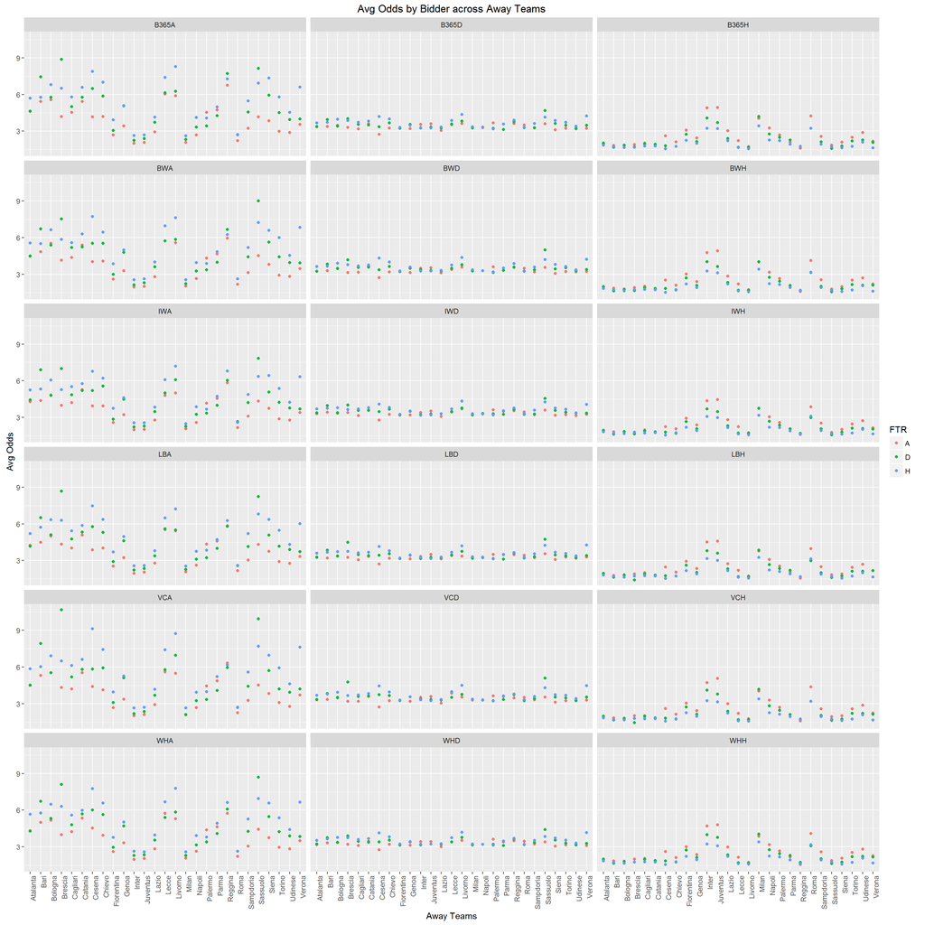

```r
query <- paste("SELECT ", paste('avg(', colnames(data)[6:23], '),', collapse = ""), " AwayTeam, FTR ",
               "FROM data
                GROUP BY AwayTeam, FTR", sep = "")
avg_data <- sqldf(query)
colnames(avg_data) <- c(paste('avg', colnames(data)[6:23], sep = "_"), "AwayTeam", "FTR")
l_avg_data <- alply(avg_data[ ,-c(19, 20)], 2, function(x){
                                                 y <- cbind(x, avg_data[ ,c(19, 20)])
                                                 colnames(y)[1] <- "Avg_Odds"
                                                 return(y)})
n_avg_data <- ldply(l_avg_data, function(x){x})
colnames(n_avg_data)[1] <- "Bid"
n_avg_data[ ,1] <- gsub("avg_", "", n_avg_data[ ,1])
ggplot(n_avg_data, aes(x = AwayTeam, y = Avg_Odds, colour = FTR)) + facet_wrap( ~Bid, nrow = 6, ncol = 3) + geom_point() + theme(axis.text.x = element_text(angle = 90, hjust = 1)) +
xlab('Away Teams') + ylab('Avg Odds') +
ggtitle('Avg Odds by Bidder across Away Teams')
```

This reflects almost mirror results of the above graph away team has low bid value of winning and the teams which have high bid value of winning home have more bid value of winning away game too.

### Conclusion

- Successfully used the ggplot2 to explore the interactions between different independent variables.